# Введение в дисперсионный анализ (ANOVA)

Контроль FWER в контексте линейных моделей

Matvei Slavenko

20.11.2024

# Данные. Генеральная совокупность и рабочая выборка.

Файл `soccer.csv`.

Работаем с футболистами: имя, позиция на поле (защитник, форвард, голкипер или полузащитник), гражданство, возраст и рост.

Размер рабочей выборки чуть больше: 150 человек.

```r
soccer_general <- read.csv("soccer.csv", sep=";")[, 2:6] %>%
  mutate(Position = as.factor(Position),
         Nationality = as.factor(Nationality),
         Age = as.numeric(Age),
         Height = as.numeric(Height)) %>%
  filter(Nationality %in% c("Spanish", "Italian", "German", "English", "Argentinian"))
```

```r
set.seed(1)

soccer_wrk <- soccer_general[sample(1:nrow(soccer_general), 150), ] %>%
  mutate(Nationality = factor(Nationality))
```

Дисклеймер: *Не совсем корректно, конечными генеральными совокупностями занимается не классическая статистика, а sample surveys. Но для сегодняшних целей пойдет.*

# В предыдущих сериях

```r
set.seed(1)

soccer_wrk %>%
  ggplot() + aes(Position, Height) +
  geom_boxplot(outlier.shape = "", colour = "cadetblue3") +
  geom_jitter(width = 0.2, colour = "cornsilk4") +
  theme_classic() +
  ylab("Height (cm)")
```

[output not shown]

- Попарные сравнения
- Попарных сравнений много, поэтому поправки
- Иными словами: а есть ли связь между позицией и средним ростом футболиста?
  - СВЯЗЬ
  - СРЕДНИМ РОСТОМ

# Условное математическое ожидание aka математический `filter(...) %>% mean`

Для каждого футболиста мы записывали его рост ($Y_i$) и позицию на поле ($D_i$). То есть i-тое наблюдение – это вектор $(Y_i; D_i)$. В прошлый раз мы занимались защитниками (defenders). Средний рост в группе защитников мы можем понимать как средний рост футболиста при условии, что он защитник -> условное среднее, conditional expectation.

Записываем так: $\mathsf{E}[Y|D = \text{Defender}]$.

*УМО – один из способов концептуализировать информацию, которую несет в себе позиция на поле о росте футболиста.*

Условный средний рост футболиста в генеральной совокупности при условии, что он защитник:

```r
soccer_general %>% filter(Position == "Defender") %>% pull(Height) %>% mean
```

```
## [1] 183.586
```

Точечная оценка среднего роста футболиста при условии, что он защитник:

```r
soccer_wrk %>% filter(Position == "Defender") %>% pull(Height) %>% mean
```

```
## [1] 183.2182
```

# В предыдущих сериях: новый взгляд

```r
set.seed(1)

soccer_wrk %>%
  ggplot() + aes(Position, Height) +
  geom_boxplot(outlier.shape = "", colour = "cadetblue3") +
  geom_jitter(width = 0.2, colour = "cornsilk4") +
  theme_classic() +
  ylab("Height (cm)")
```

[output not shown]

Обозначим реальные условные средние:
$$\begin{align*}
\mu_{Def} &= \mathsf{E}[Y| D = \text{Defender}] \\
\mu_{For} &= \mathsf{E}[Y| D = \text{Forward}] \\
\mu_{Goal} &= \mathsf{E}[Y| D = \text{Goalkeeper}] \\
\mu_{Mid} &= \mathsf{E}[Y| D = \text{Midfielder}]
\end{align*}$$

# В предыдущих сериях: новый взгляд

```r
set.seed(1)

soccer_wrk %>%
  ggplot() + aes(Position, Height) +
  geom_boxplot(outlier.shape = "", colour = "cadetblue3") +
  geom_jitter(width = 0.2, colour = "cornsilk4") +
  theme_classic() +
  ylab("Height (cm)")
```

[output not shown]

Мы тестировали:

$$\begin{gather*}
H_0^1: \mu_{Def} - \mu_{For} = 0 \qquad vs. \qquad H_1^1: \mu_{Def} -
\mu_{For} \neq 0 \\
H_0^2: \mu_{Def} - \mu_{Goal} = 0 \qquad vs. \qquad H_1^2: \mu_{Def} -
\mu_{Goal} \neq 0 \\
\ldots \\
H_0^6: \mu_{Goal} - \mu_{Mid} = 0 \qquad vs. \qquad H_1^6: \mu_{Goal} -
\mu_{Mid} \neq 0
\end{gather*}$$

# В предыдущих сериях: новый взгляд

```r
set.seed(1)

soccer_wrk %>%
  ggplot() + aes(Position, Height) +
  geom_boxplot(outlier.shape = "", colour = "cadetblue3") +
  geom_jitter(width = 0.2, colour = "cornsilk4") +
  theme_classic() +
  ylab("Height (cm)")
```

[output not shown]

- Иными словами: а есть ли связь между позицией и средним ростом футболиста?

Это можно сформулировать иначе:
$$\begin{align*}
& H_0\!: \mu_{Def} = \ldots = \mu_{Mid} \\
vs. \\
& H_1\!: \exists i,j: \mu_i \neq \mu_j
\end{align*}$$

Т.е. *“(условный) средний рост футболиста не ассоциирован с его позицией на поле”* или *“позиция игрока на поле не несет информации о среднем росте футболиста”*.

# В предыдущих сериях: новый взгляд

```r
set.seed(1)

soccer_wrk %>%
  ggplot() + aes(Position, Height) +
  geom_boxplot(outlier.shape = "", colour = "cadetblue3") +
  geom_jitter(width = 0.2, colour = "cornsilk4") +
  theme_classic() +
  ylab("Height (cm)")
```

[output not shown]

Т.е. *“(условный) средний рост футболиста не ассоциирован с его позицией на поле”* или *“позиция игрока на поле не несет информации о среднем росте футболиста”*.

- Моделированием условного математического ожидания (среднего) занимается регрессия.
- А есть ли связь между позицией и средним ростом футболиста? Такую гипотезу тестирует AN(C)OVA – Analysis of (Co)Variance – Дисперсионный / ковариационный анализ – частный случай регрессионной модели.
- *УМО – один из способов концептуализировать информацию, которую несет в себе позиция на поле о росте футболиста.*
  - Как измерить эту информацию?

# Новый взгляд на среднее и дисперсию

$$\mathsf{E}X := \int_{\mathbb{R}}
xf_X(x)dx \qquad \mathsf{var}X := \mathsf{E}\left(X -
\mathsf{E}X\right)^2$$

$$\overline{X_n} := \frac{1}{n}
\sum_{i=1}^n X_i \qquad S_n^2 := \frac{1}{n-1} \sum_{i=1}^n(X_i -
\overline{X_n})^2$$

- Среднее – это в каком-то смысле оптимальное выражение распределения одним числом.
- Дисперсия – мера (не)оптимальности – мера неопределенности.

$$\mathsf{E}X = \arg \min_{a\in\mathbb{R}}
\mathsf{E}\left(X-a\right)^2$$

- Дисперсия – это сумма квадратов.

Дополнительный кусочек пазла для самостоятельного изучения: [неравенство / теорема Чебышева](https://ru.wikipedia.org/wiki/Неравенство_Чебышёва) объясняет, что дисперсия действительно дает оценку вариабельности данных.

# Две модели для среднего

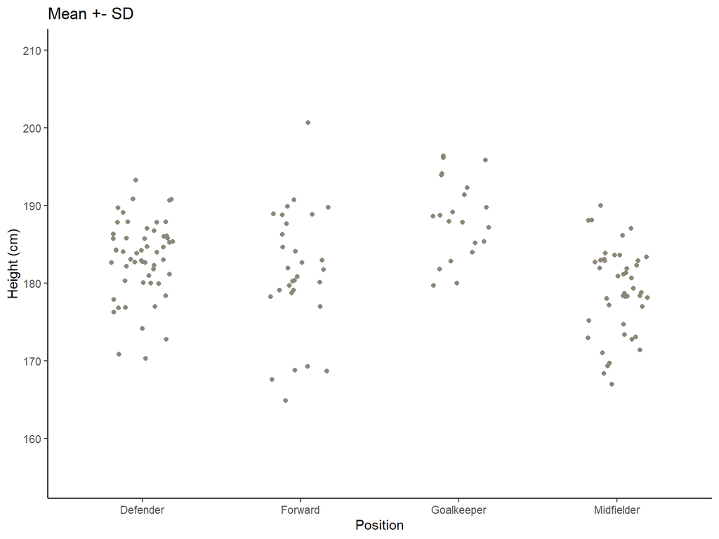

# Две модели для среднего

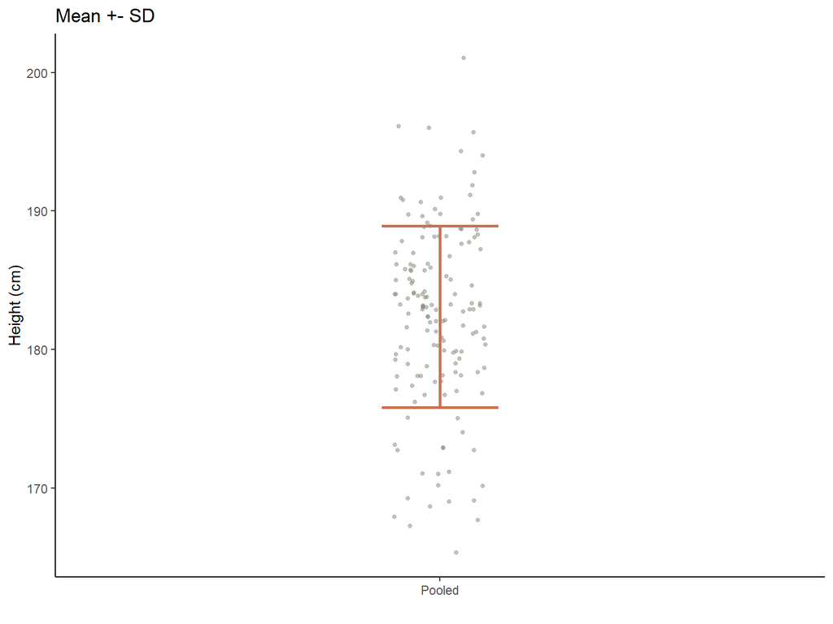

1. Простая модель M0: посчитать среднее по всем футболистам.

# Две модели для среднего

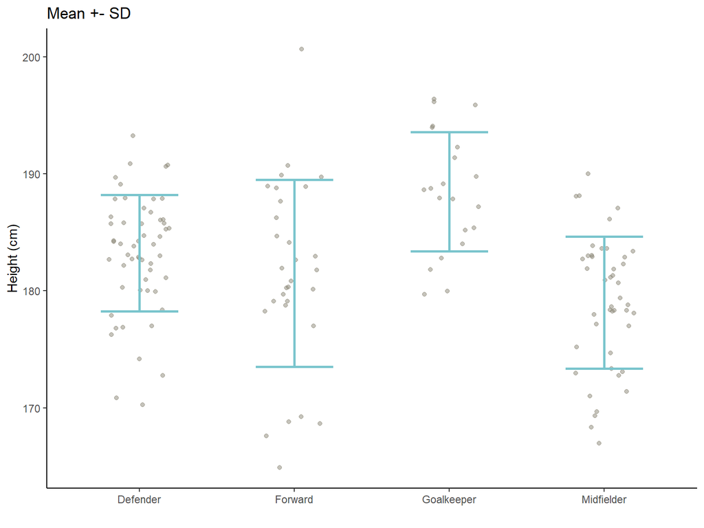

1. Простая модель M0: посчитать среднее по всем футболистам.
2. Более сложная модель М1: посчитать среднее в каждой группе отдельно.

# Две модели для среднего

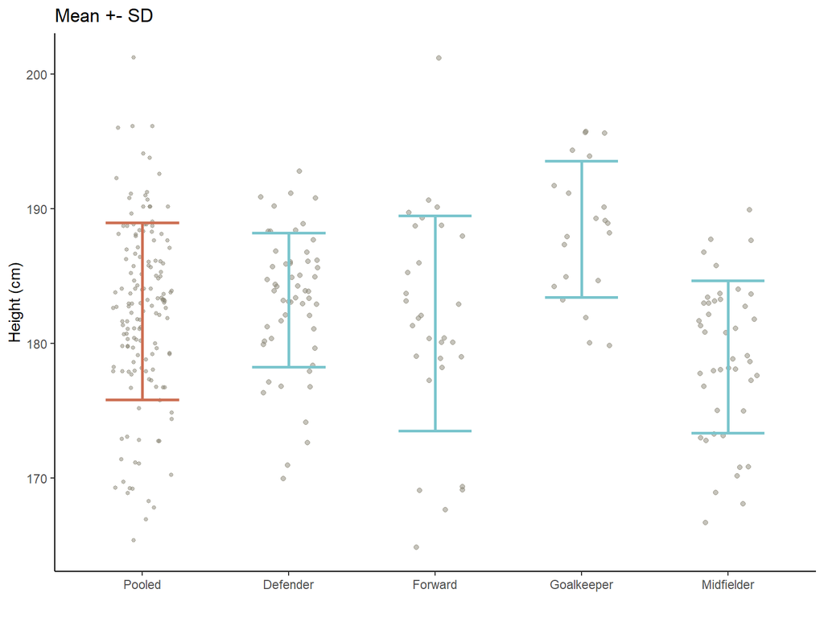

1. Простая модель M0: посчитать среднее по всем футболистам.
2. Более сложная модель М1: посчитать среднее в каждой группе отдельно.

Имеет ли смысл рассматривать более сложную модель, или простая описывает данные “достаточно хорошо”?

# Две модели для среднего

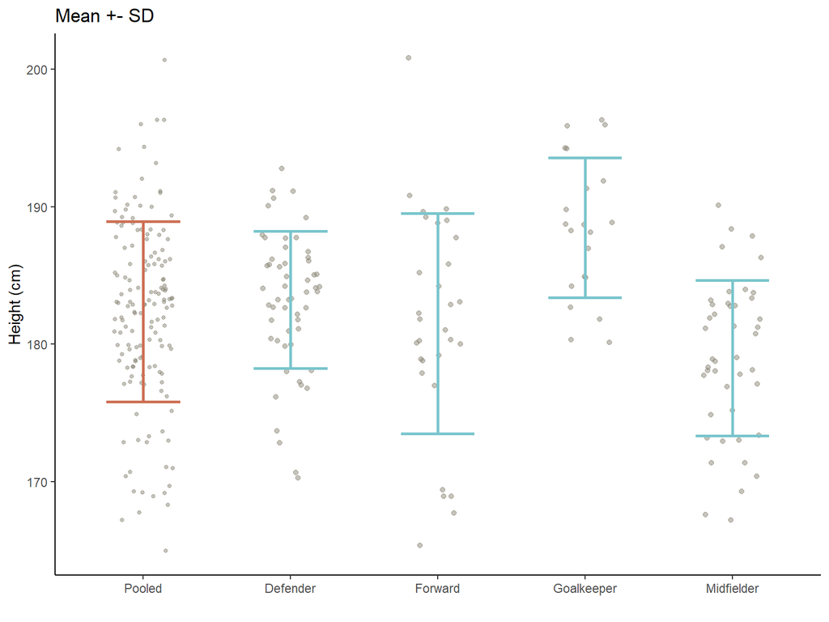

1. Простая модель M0: посчитать среднее по всем футболистам.
2. Более сложная модель М1: посчитать среднее в каждой группе отдельно.

Имеет ли смысл рассматривать более сложную модель, или простая описывает данные “достаточно хорошо”?

$$H_0\!: \mu_{Def} = \ldots = \mu_{Mid}
\quad vs. \quad H_1\!: \exists i,j: \mu_i \neq \mu_j$$

Если справедлива гипотеза, то обе модели описывают одно и то же число! Значит, если справедлива гипотеза, то оценки не должны отличаться слишком сильно. Или: conditioning позицией на поле не должен слишком сильно снижать неопределенность.

# Две модели для среднего

Если справедлива гипотеза, то обе модели описывают одно и то же число! Значит, если справедлива гипотеза, то оценки не должны отличаться слишком сильно. Или: conditioning позицией на поле не должен слишком сильно снижать неопределенность.

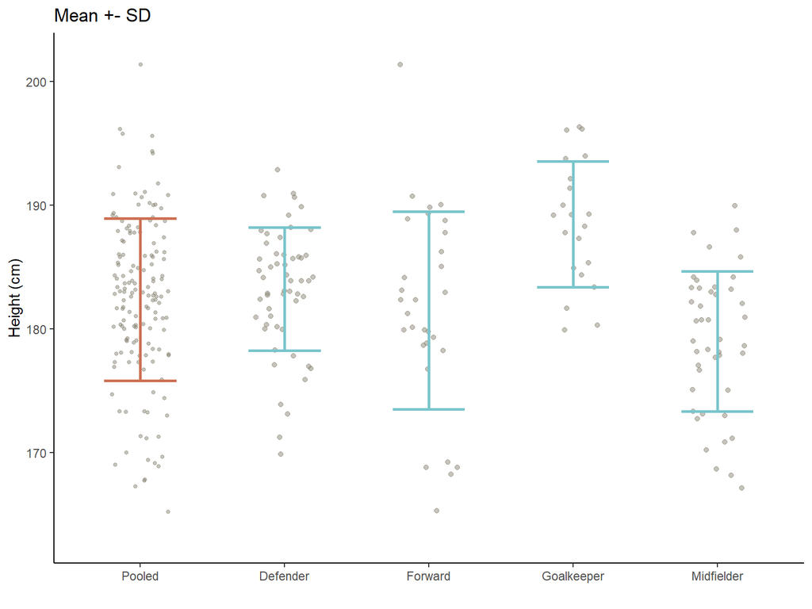

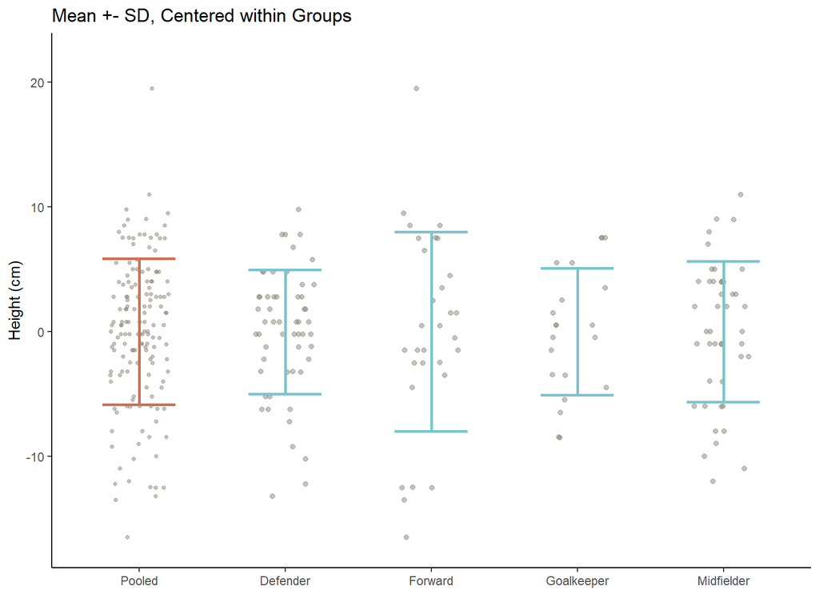

# Две модели для среднего

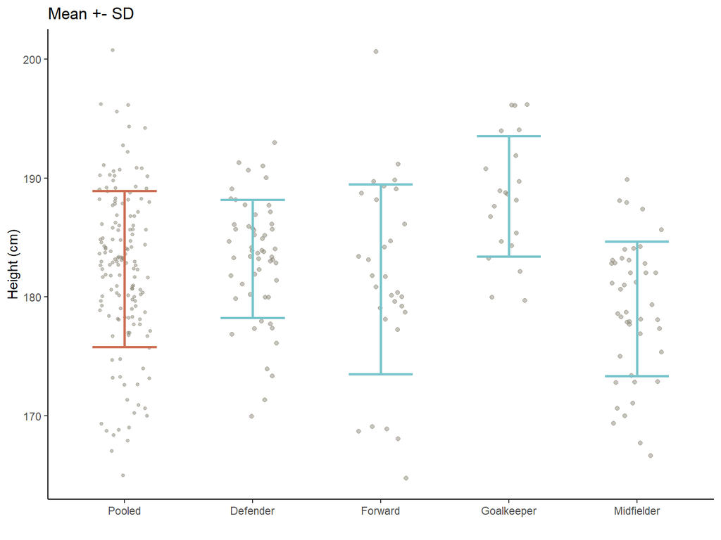

Если справедлива гипотеза, то обе модели описывают одно и то же число! Значит, если справедлива гипотеза, то оценки не должны отличаться слишком сильно. Или: conditioning позицией на поле не должен слишком сильно снижать неопределенность.

**Неопределенность простой модели M0:** дисперсия!

$$S_n^2 := \frac{1}{n-1} \sum_{i=1}^n(Y_i
- \overline{Y_n})^2$$

Ну, или как сумма квадратов (полная, total sum of squares):

$$SS_T := \sum_{i=1}^n(Y_i -
\overline{Y_n})^2$$

# Две модели для среднего

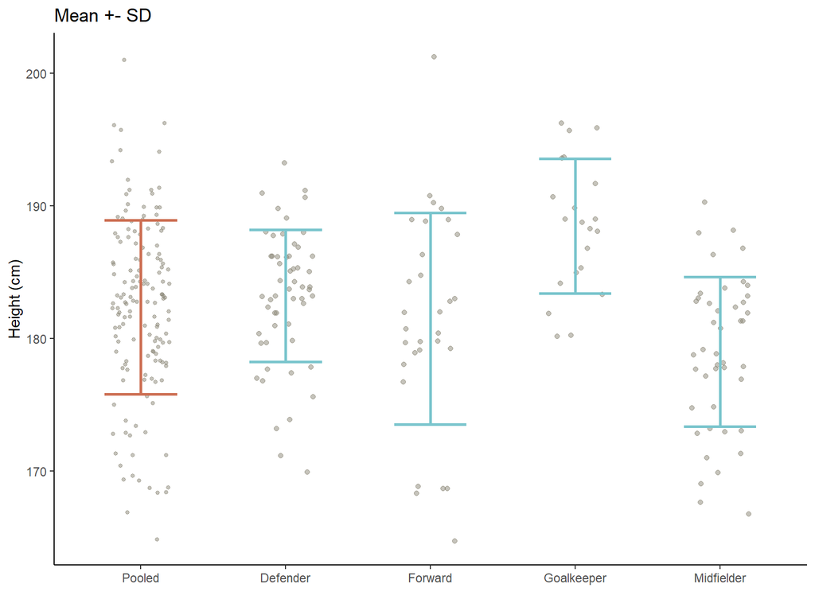

Если справедлива гипотеза, то обе модели описывают одно и то же число! Значит, если справедлива гипотеза, то оценки не должны отличаться слишком сильно. Или: conditioning позицией на поле не должен слишком сильно снижать неопределенность.

**Неопределенность сложной модели M1:** дисперсия!

Ну, почти. Поправим формулу так, чтобы мы учитывали то, что в разных группах, возможно, разные средние. Обозначим среднее, посчитанное в группе $D$, как $\widehat{\mu}_{D_i}$.

$$S_n^2 := \frac{1}{n-1} \sum_{i=1}^n(Y_i
- \widehat{\mu}_{D_i})^2$$

Ну, или как сумма квадратов (остаточная, residual sum of squares):

$$SS_e := \sum_{i=1}^n(Y_i -
\widehat{\mu}_{D_i})^2$$

# Две модели для среднего

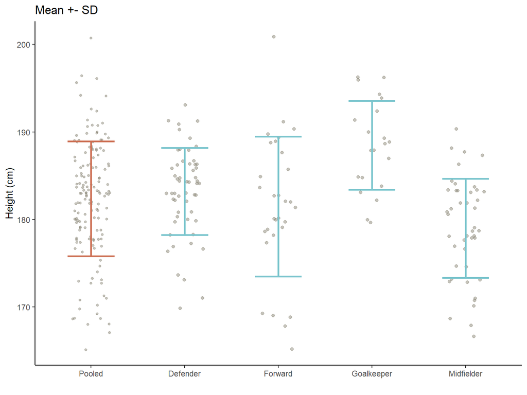

Если справедлива гипотеза, то обе модели описывают одно и то же число! Значит, если справедлива гипотеза, то оценки не должны отличаться слишком сильно. Или: conditioning позицией на поле не должен слишком сильно снижать неопределенность.

**Неопределенность простой модели M0:** полная сумма квадратов $SS_T := \sum_{i=1}^n(Y_i - \overline{Y_n})^2$ **Неопределенность сложной модели M1:** остаточная сумма квадратов $SS_e := \sum_{i=1}^n(Y_i - \widehat{\mu}_{D})^2$

Посчитаем, какой процент неопределенности был “объяснен” позицией на поле:

$$\frac{SS_T - SS_e}{SS_T}$$

Кажется, это может быть интересная метрика (спойлер: это же $R^2$)!

# Две модели для среднего. F-test

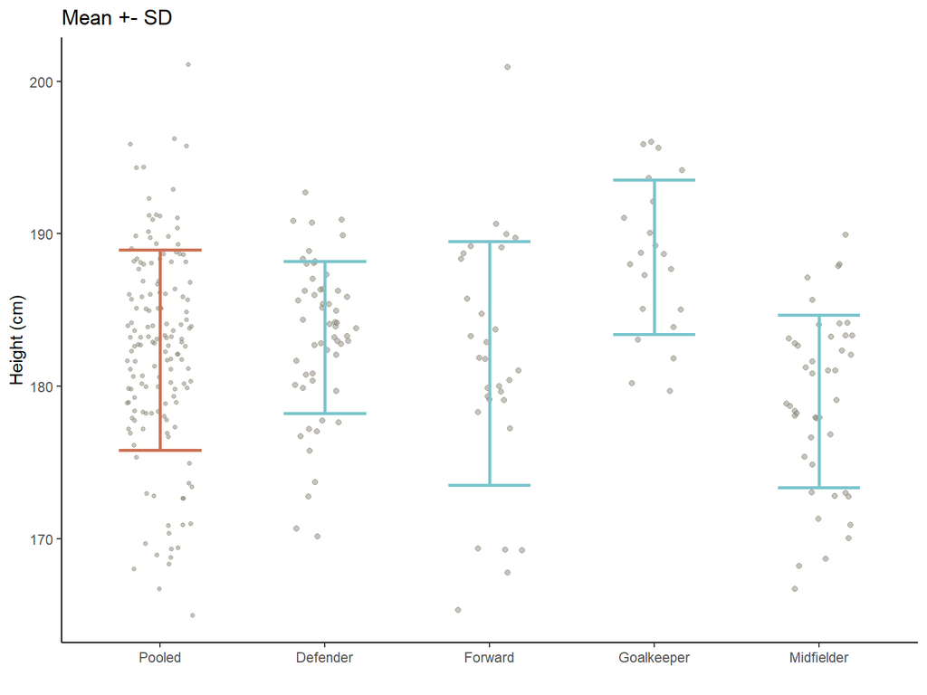

Чтобы тестировать, нам нужно знать распределение тестовой статистики. Используют:

$$F := \frac{\frac{SS_T -
SS_e}{K-1}}{\frac{SS_e}{n-K}}$$

$K$ – количество групп.

$n$ – количество наблюдений.